# Who’s Suing Matters: Legal Representation and the Structure of Debt Collection in Virginia (2014–2024)

Team Challengers: Final Project

Addison Parman, Brett Navarro, Jonah Wilentz

April 2026

# I. Introduction & Research Question

**Research question:** In Virginia’s warrant-in-debt cases, how much of the change in legal representation between 2014 and 2024 reflects real improvements in defendants’ access to counsel, and how much is driven by shifts in *who is suing*, *where they file*, and *which communities bear the highest burden*?

Debt collection lawsuits are the single most common civil case type in Virginia and many other states. Millions of low-income Americans are sued each year, most without a lawyer. This analysis uses Virginia General District Court records from virginiacourtdata.org (the Online Case Information System) to trace how representation patterns shifted between 2014 and 2024, and to show that the *identity of the plaintiff* and the *economic profile of the community* are central to understanding the representation gap.

# II. Data & Methods

## Variable construction

### Legal representation (corrected)

Previously, we treated `NA` as the only indicator of no legal representation. But the attorney fields contain other values that also mean no attorney is present — things like `SELF-REPRESENTED`, `SELF`, `PRO SE`, `NON`, and `NULL`. Following the approach from the week 4 class example, we use `str_detect()` to catch these patterns before building the `legal_rep` variable.

This correction is itself a methodological finding: naive approaches to measuring representation in court data produce misleading results. Before correction, defendant representation appeared higher than what legal aid practitioners report, because self-represented litigants were being counted as having counsel.

### Plaintiff classification

A key part of our analysis is understanding *who* is filing these cases. Rickard (2020) documents that debt collection lawsuits have become the single most common civil case type in many states (Virginia included) and that this transformation has fundamentally changed how state courts operate. Pew’s review of studies from 2010 to 2019 found that fewer than 10% of debt collection defendants had a lawyer, compared to nearly all plaintiffs, and that over 70% of cases nationally ended in default judgment. Pew identifies a mechanism: lawsuits filed by debt buyers (mostly companies the defendant has never heard of) are less likely to receive a response at all. The *composition* of who is suing shapes not just representation rates but whether defendants even engage with the process.

We used `str_detect()` and `str_to_lower()` from `stringr` to search for keywords in plaintiff names and sort them into categories.

```
## # A tibble: 7 × 3
##   plaintiff_type             n   pct
##   <chr>                  <int> <dbl>
## 1 Other/Unclassified   1199567  37.9
## 2 Medical/Health        600894  19
## 3 Bank/Credit Union     464733  14.7
## 4 Debt Buyer/Collector  450299  14.2
## 5 Government            367566  11.6
## 6 Utility                46317   1.5
## 7 Landlord/Property      37009   1.2
```

### Demographic context (Census data)

We use `tidycensus` to pull county-level demographic characteristics from the ACS 5-year estimates (2022). The 5-year ACS is necessary for Virginia localities (many are too small for the 1-year ACS), and a single cross-section serves as a solid midpoint for relatively slow-changing demographics.

Median household income is a particularly important variable for this analysis. It serves as our primary measure of a community’s economic position, and it connects our two main threads: we use it to show both *where* different plaintiff types concentrate their filings and *how* defendant representation varies across the income spectrum. A locality with a median household income of $40,000 faces a fundamentally different legal landscape than one at $100,000 — not because the law is different, but because the residents’ ability to retain counsel, take time off work for court appearances, and navigate the legal system is largely shaped by economic resources.

```
## Rows in locality summary: 124
```

```
## Rows after merge: 124
```

```
## Rows with demographic data: 124
```

```
## Rows missing demographic data: 0
```

# III. Key Findings

## A. The Representation Asymmetry

```
## # A tibble: 12 × 8
##     Year `Total Cases` `Plaintiff Rep %` `Defendant Rep %` `Both Rep %`
##    <dbl>         <int>             <dbl>             <dbl>        <dbl>
##  1  2013        300537              61.3               2.3          1.9
##  2  2014        280878              60.7               2.6          2.1
##  3  2015        285565              64.7               2.5          2
##  4  2016        279579              68.1               2.7          2.2
##  5  2017        317932              69.4               2.5          2.1
##  6  2018        317993              72.2               2.6          2.1
##  7  2019        333280              75.3               2.3          2
##  8  2020        206909              81.2               4.2          3.4
##  9  2021        207270              81.3               6            4.9
## 10  2022        183421              78.8               3.8          3.1
## 11  2023        213040              79.4               3.4          2.8
## 12  2024        239981              82.5               3            2.5
## # ℹ 3 more variables: `Plaintiff Only %` <dbl>, `Defendant Only %` <dbl>,
## #   `Neither %` <dbl>
```

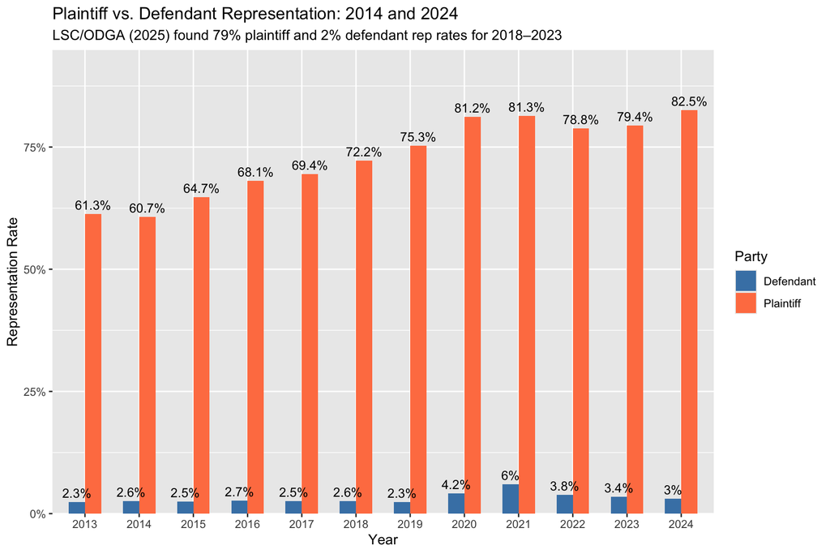

The gap between plaintiff and defendant representation dwarfs any year-over-year movement. Even a doubling of defendant representation would still leave the vast majority of defendants without counsel.

## B. Who Is Suing Matters

This is the core finding of our project As Rickard (2020) documents, the rise of debt buyers as plaintiffs has reshaped state civil courts nationally. Our data show that the *type* of plaintiff is strongly associated with both representation rates and the communities where cases are filed, making plaintiff composition a key driver of the patterns we see here.

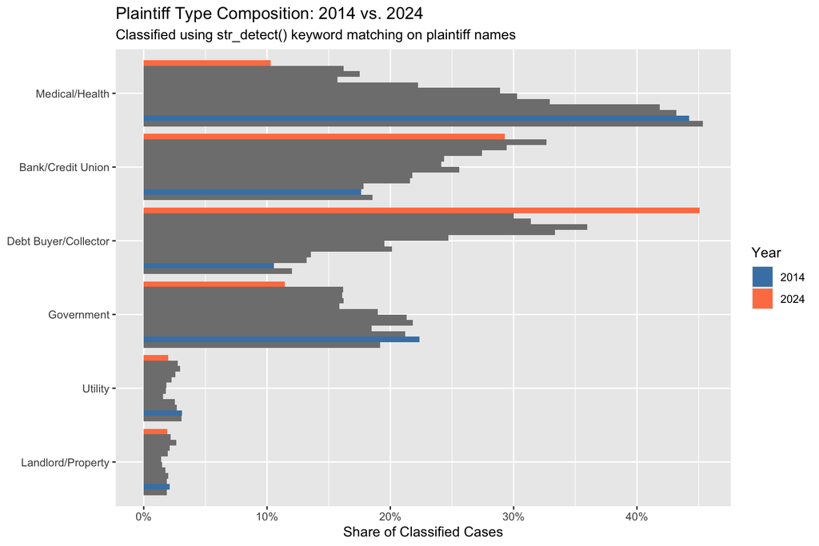

### Representation by plaintiff type

The representation asymmetry is not uniform, it varies dramatically by who is doing the suing. This is consistent with what LSC/ODGA (2025) found: 79% of debt collectors had legal representation compared to just 2% of consumers, and in contested cases, represented consumers won favorable judgments at 11 times the rate of unrepresented consumers.

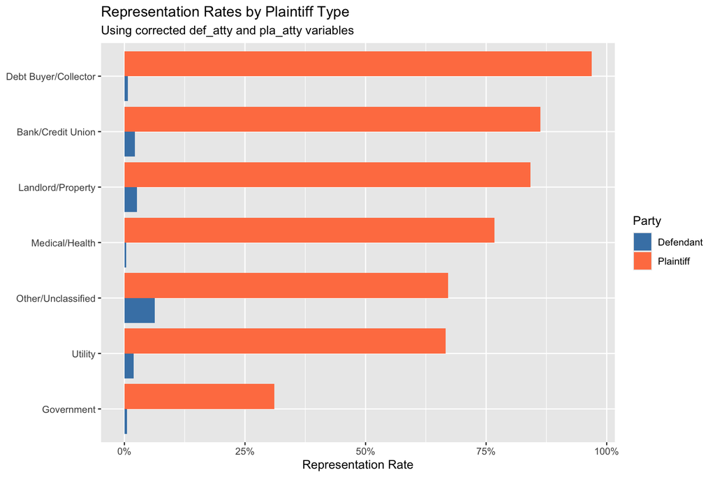

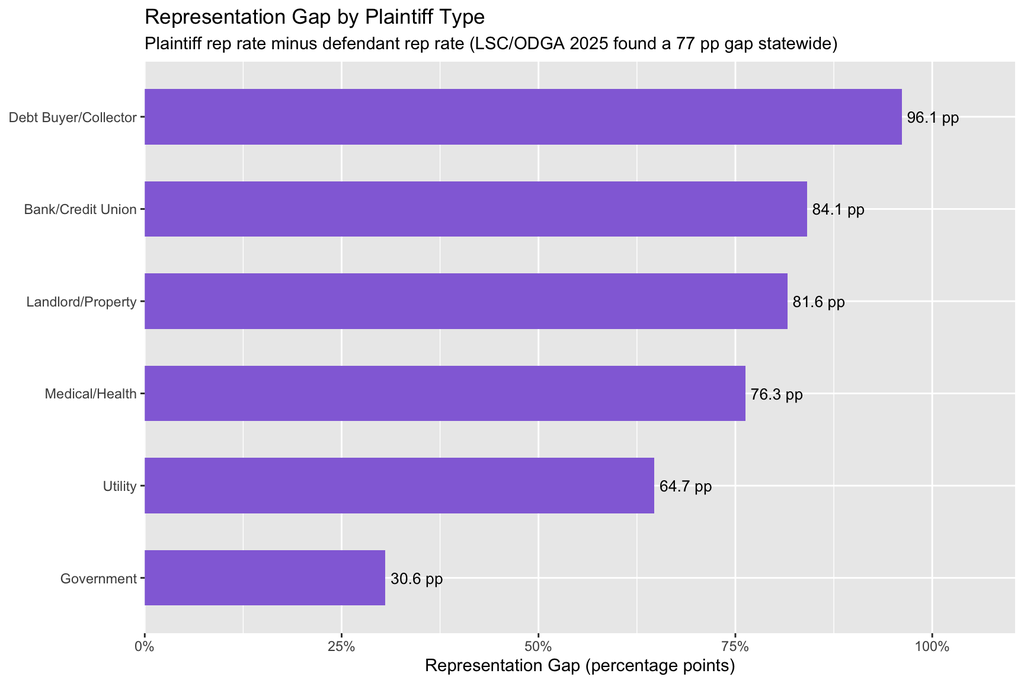

### The UVA story

UVA’s aggressive medical debt collection practices received significant public scrutiny around 2019, leading to policy changes. Since we treat all UVA plaintiffs as likely medical debt cases (per Professor Claibourn’s guidance), we can check whether their filings differ between 2014 (before the policy change) and 2024 (after it). This is a concrete example of how plaintiff behavior (not just defendant resources) shapes the landscape.

```
## Total UVA cases: 19174
```

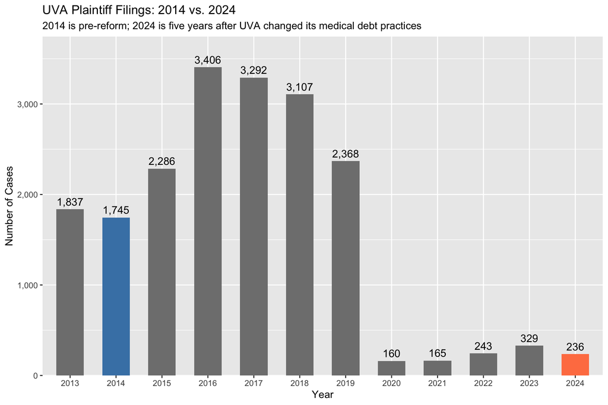

## C. Who Is Suing Where: Plaintiff Types and Community Income

The “who’s suing matters” finding becomes even more consequential when we examine *where* different plaintiff types concentrate their filings. This is where median household income comes into play.

Median household income captures a community’s overall economic position in a way that directly relates to the legal representation question. In lower-income localities, residents are less likely to be able to afford an attorney, less likely to have flexible work schedules that allow them to appear in court, and less likely to have the financial literacy and legal knowledge to navigate the system on their own. If institutional plaintiffs — the ones with the widest representation gaps — disproportionately file in these communities, then the justice gap is not randomly distributed, but concentrated precisely where people are most vulnerable.

The chart below answers a critical question: are the plaintiff types with the largest representation gaps also the ones filing in the poorest communities? For each plaintiff type, we compute the case-weighted average median household income of the localities where they file. This tells us not just *where* a plaintiff type has any presence, but where the *bulk* of their cases land. If debt buyers and medical collectors (who carry representation gaps of 70+ percentage points) are concentrated in localities with the lowest median incomes, then the structural asymmetry of the system is not just large, but likely targeted.

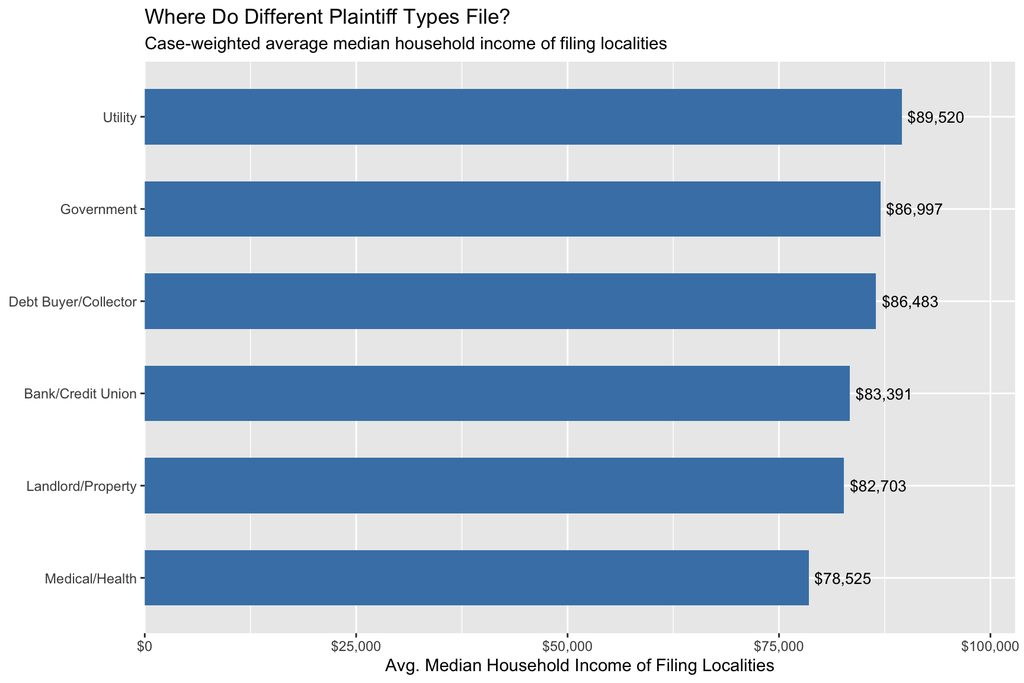

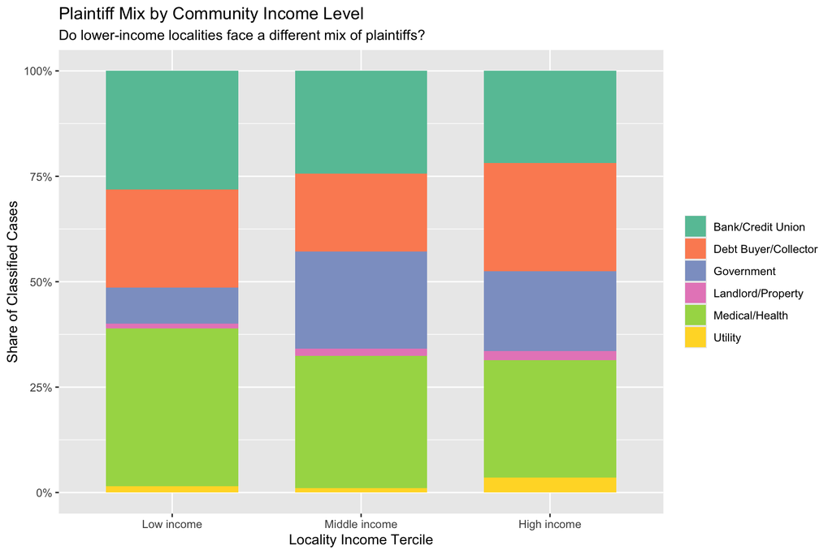

## D. The Double Burden: Filing Rates, Income, and Representation

The relationship between community income and the representation gap extends beyond plaintiff type. Lower-income localities face a compounding disadvantage: they are sued more often *and* represented less!

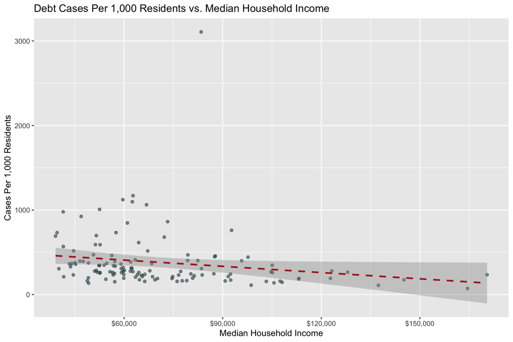

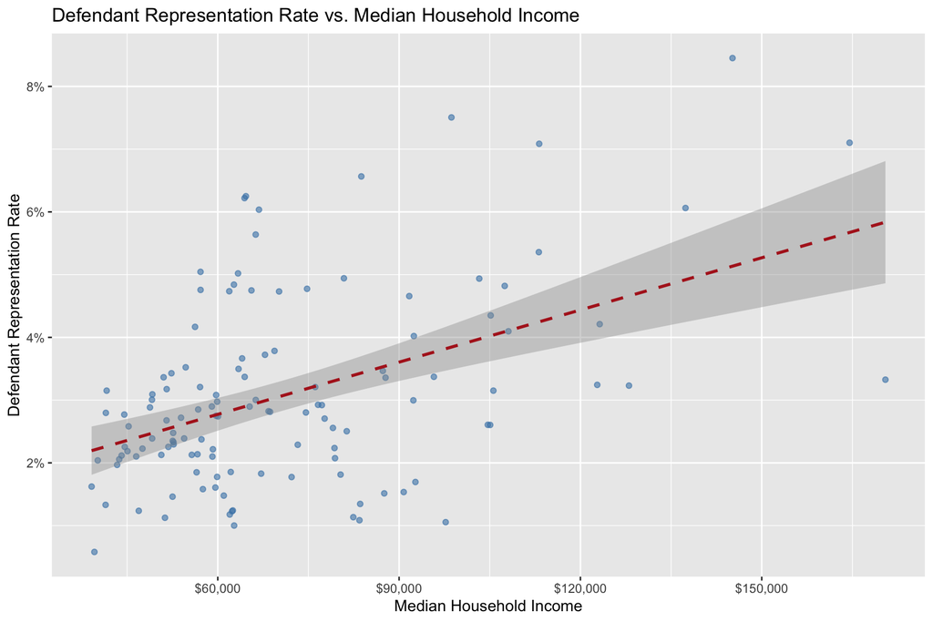

### Representation over time by community type

Splitting localities into income terciles lets us check whether the representation gap is narrowing in lower-income communities or remaining entrenched.

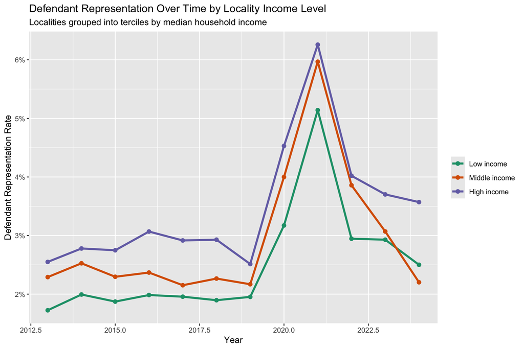

# IV. Discussion & Interpretation

The representation gap in Virginia debt collection is deep, persistent, and structurally produced by the types of plaintiffs who dominate the system:

**Who is suing shapes the gap.** Debt buyers and institutional creditors almost always bring attorneys; their defendants almost never have one. The representation gap varies dramatically by plaintiff type, meaning that shifts in the plaintiff landscape can mechanically move the statewide representation rate without any change in defendants’ actual access to counsel.

**What we cannot yet say:** We cannot determine whether defendant representation actually changes case outcomes, though LSC/ODGA (2025) found that represented consumers win at 11 times the rate of unrepresented ones. We cannot identify which specific legal aid programs are responsible for any within-locality gains. And we cannot rule out that changes in how attorney fields are recorded over time may create artificial trends.

# V. Limitations & Next Steps

**Limitations:** This analysis relies on two primary snapshot years (2014 and 2024) with intervening years for context. The plaintiff classifier is keyword-based and leaves a substantial “Other/Unclassified” category. We use a single Census cross-section (2022 ACS 5-year) rather than year-matched demographic estimates. And the analysis is observational — we can document associations between plaintiff types, community characteristics, and representation, but cannot establish causal relationships.

**Next steps:** Outcome analysis — connecting representation to plaintiff win rates, default judgments, and fee imposition — would quantify the stakes of the representation gap. Legal aid funding data from nonprofit tax records could help explain within-locality variation. And spatial mapping of filing rates and representation across Virginia would make the geographic concentration of the burden visible.

# VI. Conclusion

The story of legal representation in Virginia debt collection dominated by institutional plaintiffs who almost always bring attorneys, suing individual defendants who almost never have one. This asymmetry is produced by the types of creditors who file the most cases, and it falls hardest on the lowest-income communities in the state.

Apparent changes in statewide representation rates (whether up or down) cannot be read at face value. Our plaintiff classification and demographic analysis point to the same conclusion: compositional shifts in who is suing and where they file can create the appearance of changing access without any real change in whether defendants can get a lawyer.

# References

Gelbach, J. B. (2011). Empirical patterns of pro se litigation in federal district courts. *University of Chicago Law Review*, *78*(4). https://lawreview.uchicago.edu/print-archive/empirical-patterns-pro-se-litigation-federal-district-courts

Legal Services Corporation. (2022). *The justice gap: The unmet civil legal needs of low-income Americans*. https://www.lsc.gov/initiatives/justice-gap-research

Legal Services Corporation, Office of Data Governance and Analysis. (2025). *Legal representation in Virginia: Debt collection and eviction cases.* https://civilcourtdata.lsc.gov/research/our-work/va-2023-eviction-and-debt

Rickard, E. J. (2020). *How debt collectors are transforming the business of state courts.* The Pew Charitable Trusts. https://www.pewtrusts.org/en/research-and-analysis/reports/2020/05/how-debt-collectors-are-transforming-the-business-of-state-courts

Sleight, A. (2025, February 7). Virginia sees surge in civil lawsuits in 2024: How to avoid collection and eviction litigation. *Offit Kurman*. https://www.offitkurman.com/offit-kurman-blogs/virginia-sees-surge-in-civil-lawsuits-in-2024-how-to-avoid-collection-and-eviction-litigation